# P1650 Report Parts

2022-06-01

# Key demographics

## Personal annual income

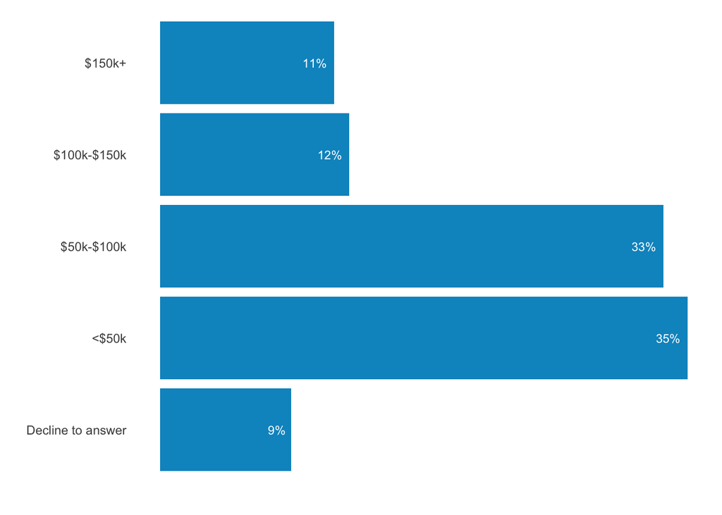

```r
tmp <- as.data.frame(svytable(~q131r, sch.w))
tmp$perc <- tmp$Freq/sum(tmp$Freq)
names(tmp)[1] <- "var"

strada1(tmp)
```

## Employment

**QUESTION:** This currently combines CATA responses without deduplication. Do we report all responses or add a Multiple option? For example, Full time (for employer) + Part time (for self) = ? Currently these are counted as 1 FT and 1 PT so the sum of the responses for this is greater than the number of respondents.

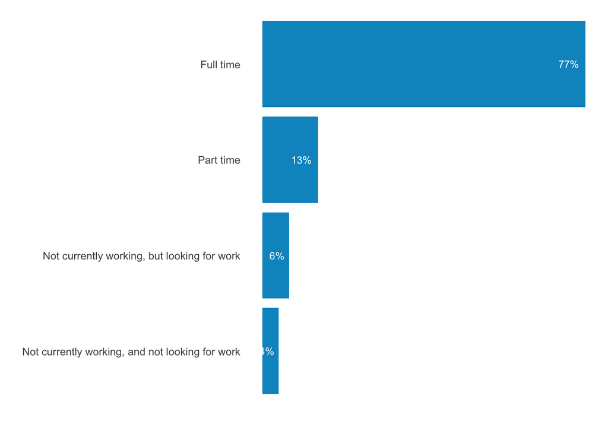

```r
tmp <- tibble(
  q82 = svytable(~q82r, sch.w),
  q83 = svytable(~q83r, sch.w),
  q84 = svytable(~q84r, sch.w),
  q85 = svytable(~q85r, sch.w),
  q86 = svytable(~q86r, sch.w),
  q87 = svytable(~q87r, sch.w)
)

tmp <- as.data.frame(t(tmp))

tmp <- rownames_to_column(tmp, "qnum")

tmp$emp <- c("Full time",
             "Full time",
             "Part time",
             "Part time",
             "Not currently working, but looking for work",
             "Not currently working, and not looking for work"
             )

tmp$emp <- factor(tmp$emp,
                  levels = c("Full time",
                         "Part time",
                         "Not currently working, but looking for work",
                         "Not currently working, and not looking for work"
                         )
                  )

tmp <- tmp %>% group_by(emp) %>% summarize(V2 = sum(V2))

tmp$perc <- tmp$V2/sum(tmp$V2)
names(tmp)[1] <- "var"

strada1(tmp)
```

# Parent’s Education

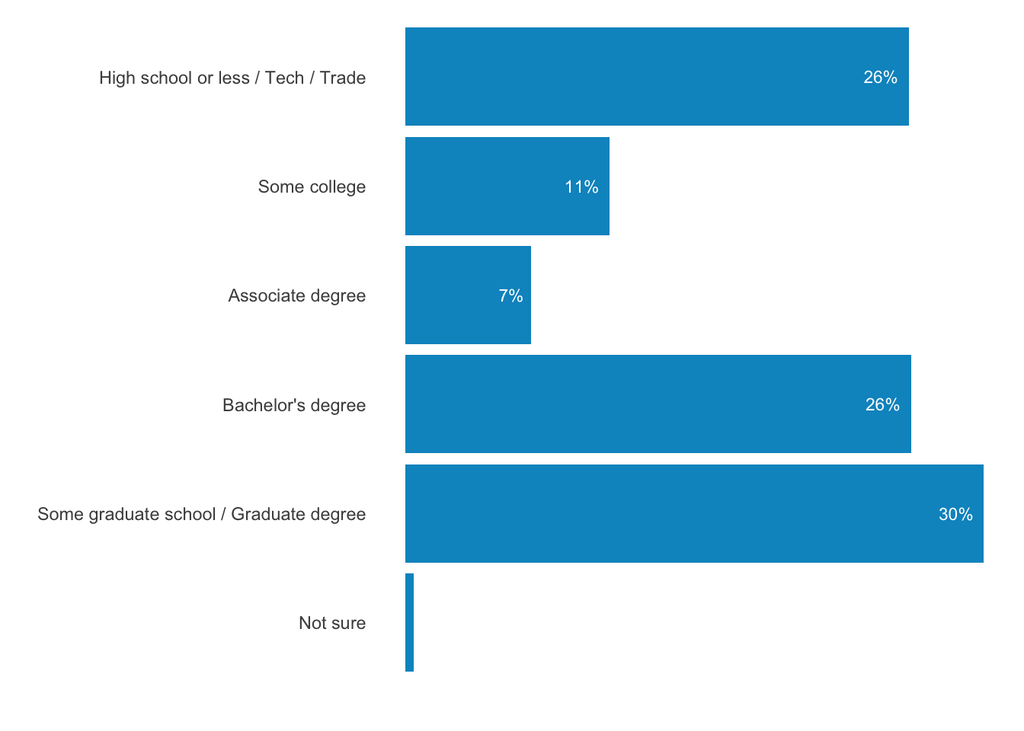

```r
tmp <- as.data.frame(svytable(~q128, sch.w))

tmp$edu <- c("High school or less / Tech / Trade",
             "High school or less / Tech / Trade",
             "High school or less / Tech / Trade",
             "Some college",
             "Associate degree",
             "Bachelor's degree",
             "Some graduate school / Graduate degree",
             "Some graduate school / Graduate degree",
             "Not sure",
             "Some graduate school / Graduate degree"
             )

tmp$edu <- factor(tmp$edu,
                  levels = c("High school or less / Tech / Trade",
                             "Some college",
                             "Associate degree",
                             "Bachelor's degree",
                             "Some graduate school / Graduate degree",
                             "Not sure"
                             )
                  )

tmp <- tmp %>% group_by(edu) %>% summarize(Freq = sum(Freq))

tmp$perc <- tmp$Freq/sum(tmp$Freq)

names(tmp)[1] <- "var"

strada1(tmp)
```

## Graduate education of alumni

**Question:** How to combine these into No grad, some grad, and grad/prof?

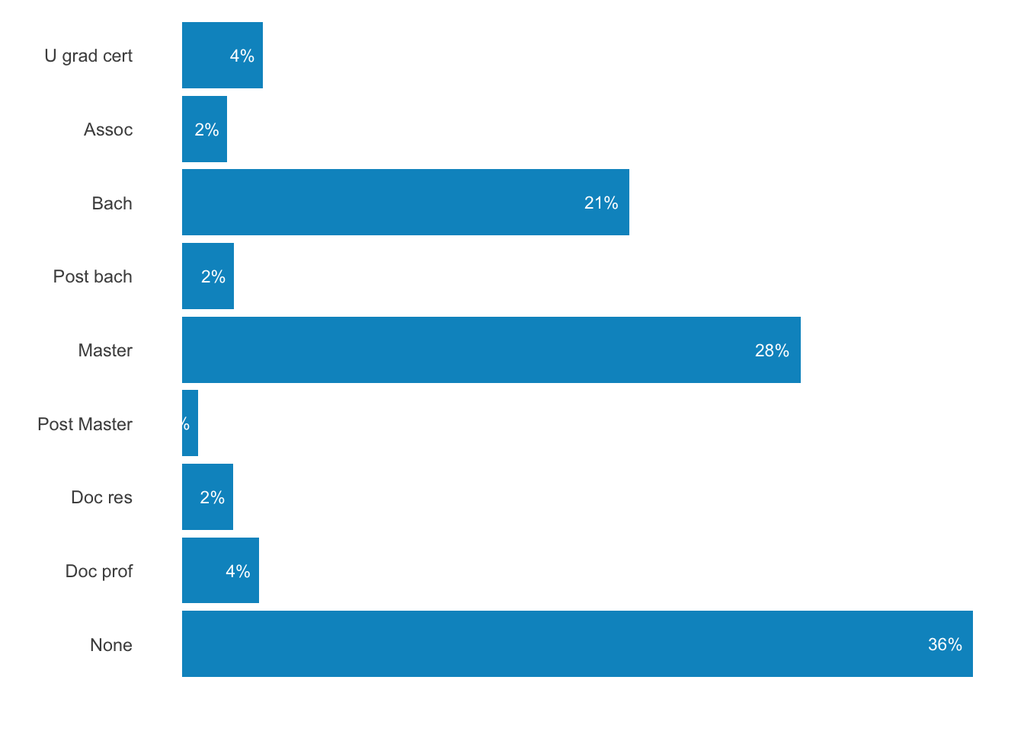

```r
tmp <- tibble(
  q21 = svytable(~q21r, sch.w),
  q22 = svytable(~q22r, sch.w),
  q23 = svytable(~q23r, sch.w),
  q24 = svytable(~q24r, sch.w),
  q25 = svytable(~q25r, sch.w),
  q26 = svytable(~q26r, sch.w),
  q27 = svytable(~q27r, sch.w),
  q28 = svytable(~q28r, sch.w),
  q29 = svytable(~q29r, sch.w),
)

tmp <- as.data.frame(t(tmp))

tmp <- rownames_to_column(tmp, "qnum")

tmp$edu <- c("U grad cert",
             "Assoc",
             "Bach",
             "Post bach",
             "Master",
             "Post Master",
             "Doc res",
             "Doc prof",
             "None"
             )

tmp$edu <- factor(tmp$edu,
                  levels = c("U grad cert",
             "Assoc",
             "Bach",
             "Post bach",
             "Master",
             "Post Master",
             "Doc res",
             "Doc prof",
             "None"
             )
)


tmp <- tmp %>% group_by(edu) %>% summarize(V2 = sum(V2))

tmp$perc <- tmp$V2/sum(tmp$V2)

names(tmp)[1] <- "var"

strada1(tmp)
```

## Demographic Profile: Top Majors

**Question:** Combine these into Engineering, Business, Computer like example? Collapse some other way?

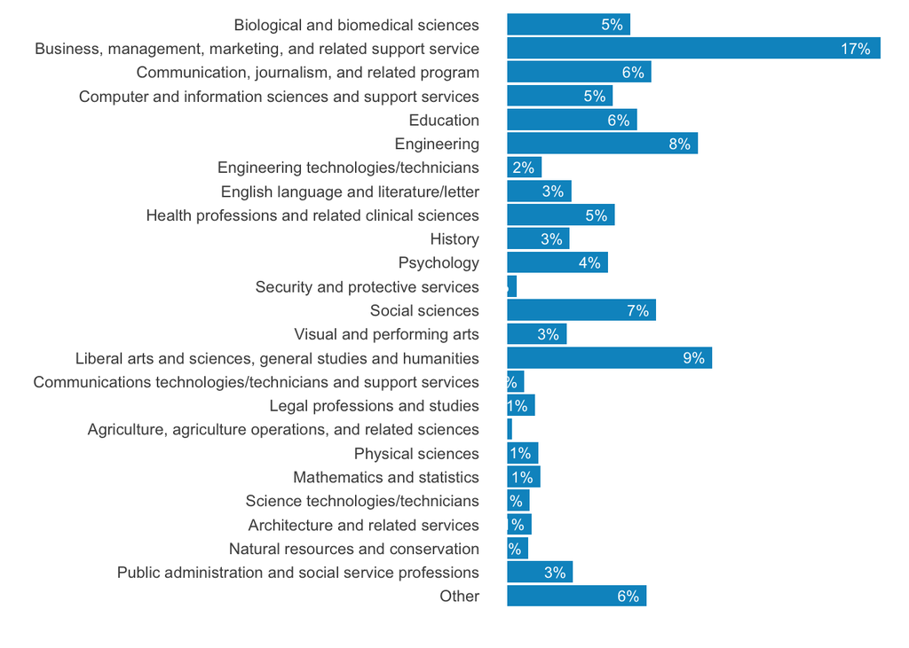

```r
tmp <- tibble(
  q135 = svytable(~q135, sch.w),
  q136 = svytable(~q136, sch.w),
  q137 = svytable(~q137, sch.w),
  q138 = svytable(~q138, sch.w),
  q139 = svytable(~q139, sch.w),
  q140 = svytable(~q140, sch.w),
  q141 = svytable(~q141, sch.w),
  q142 = svytable(~q142, sch.w),
  q143 = svytable(~q143, sch.w),
  q144 = svytable(~q144, sch.w),
  q145 = svytable(~q145, sch.w),
  q146 = svytable(~q146, sch.w),
  q147 = svytable(~q147, sch.w),
  q148 = svytable(~q148, sch.w),
  q149 = svytable(~q149, sch.w),
  q150 = svytable(~q150, sch.w),
  q151 = svytable(~q151, sch.w),
  q152 = svytable(~q152, sch.w),
  q153 = svytable(~q153, sch.w),
  q154 = svytable(~q154, sch.w),
  q155 = svytable(~q155, sch.w),
  q156 = svytable(~q156, sch.w),
  q157 = svytable(~q157, sch.w),
  q158 = svytable(~q158, sch.w),
  q159 = svytable(~q159, sch.w)
)

tmp <- as.data.frame(t(tmp))

tmp <- rownames_to_column(tmp, "qnum")

tmp$var <- c(
  "Biological and biomedical sciences",
  "Business, management, marketing, and related support service",
  "Communication, journalism, and related program",
  "Computer and information sciences and support services",
  "Education",
  "Engineering",
  "Engineering technologies/technicians",
  "English language and literature/letter",
  "Health professions and related clinical sciences",
  "History",
  "Psychology",
  "Security and protective services",
  "Social sciences",
  "Visual and performing arts",
  "Liberal arts and sciences, general studies and humanities",
  "Communications technologies/technicians and support services",
  "Legal professions and studies",
  "Agriculture, agriculture operations, and related sciences",
  "Physical sciences",
  "Mathematics and statistics",
  "Science technologies/technicians",
  "Architecture and related services",
  "Natural resources and conservation",
  "Public administration and social service professions",
  "Other"
  )

tmp$var <- factor(
  tmp$var,
  levels = c(
    "Biological and biomedical sciences",
    "Business, management, marketing, and related support service",
    "Communication, journalism, and related program",
    "Computer and information sciences and support services",
    "Education",
    "Engineering",
    "Engineering technologies/technicians",
    "English language and literature/letter",
    "Health professions and related clinical sciences",
    "History",
    "Psychology",
    "Security and protective services",
    "Social sciences",
    "Visual and performing arts",
    "Liberal arts and sciences, general studies and humanities",
    "Communications technologies/technicians and support services",
    "Legal professions and studies",
    "Agriculture, agriculture operations, and related sciences",
    "Physical sciences",
    "Mathematics and statistics",
    "Science technologies/technicians",
    "Architecture and related services",
    "Natural resources and conservation",
    "Public administration and social service professions",
    "Other"
  )
)


#tmp <- tmp %>% group_by(var) %>% summarize(V1 = sum(V1))

tmp$perc <- tmp$V1/sum(tmp$V1)

tmp <- tmp %>% select(var, perc)

strada1(tmp)
```

## Current occupation

```r
tmp <- as.data.frame(svytable(~q92, sch.w))

tmp$var <- c(
  "Education, training, and library occupations",
  "Management occupations",
  "Business and financial operations occupation",
  "Computer, engineering, and science occupations",
  "Community service, social service, legal, arts, design, entertainment, sports and media occupation",
  "Healthcare",
  "Service occupation",
  "Sales and related occupation",
  "Office and administrative support occupation",
  "Natural resources, construction, and maintenance occupations",
  "Production, transportation, and material moving occupations",
  "Other"
)

tmp$var <- factor(
  tmp$var,
  levels = c(
  "Education, training, and library occupations",
  "Management occupations",
  "Business and financial operations occupation",
  "Computer, engineering, and science occupations",
  "Community service, social service, legal, arts, design, entertainment, sports and media occupation",
  "Healthcare",
  "Service occupation",
  "Sales and related occupation",
  "Office and administrative support occupation",
  "Natural resources, construction, and maintenance occupations",
  "Production, transportation, and material moving occupations",
  "Other"
  ),
  labels = c(
  "Education, training,\n and library occupations",
  "Management occupations",
  "Business and financial\n operations occupation",
  "Computer, engineering,\n and science occupations",
  "Community service, social service,\n legal, arts, design, entertainment,\n sports and media occupation",
  "Healthcare",
  "Service occupation",
  "Sales and related\n occupation",
  "Office and administrative\n support occupation",
  "Natural resources, construction,\n and maintenance occupations",
  "Production, transportation,\n and material moving occupations",
  "Other"
  )

)

tmp$perc <- tmp$Freq/sum(tmp$Freq)

tmp$perc1 <- scales::percent(tmp$Freq/sum(tmp$Freq), 1.0)

tmp2 <- tmp[c(1, 5)]
names(tmp2) <- c("Current occupation", "Percent")

kable(tmp2)
```

| Current occupation | Percent |
| --- | --- |
| Education, training, and library occupations | 16% |
| Management occupations | 9% |
| Business and financial operations occupations | 15% |
| Computer, engineering, and science occupations | 17% |
| Community service, social service, legal, arts, design, entertainment, sports and media occupations | 8% |
| Healthcare | 9% |
| Service occupations | 2% |
| Sales and related occupations | 5% |
| Office and administrative support occupations | 6% |
| Natural resources, construction, and maintenance occupations | 1% |
| Production, transportation, and material moving occupations | 1% |
| Other | 13% |

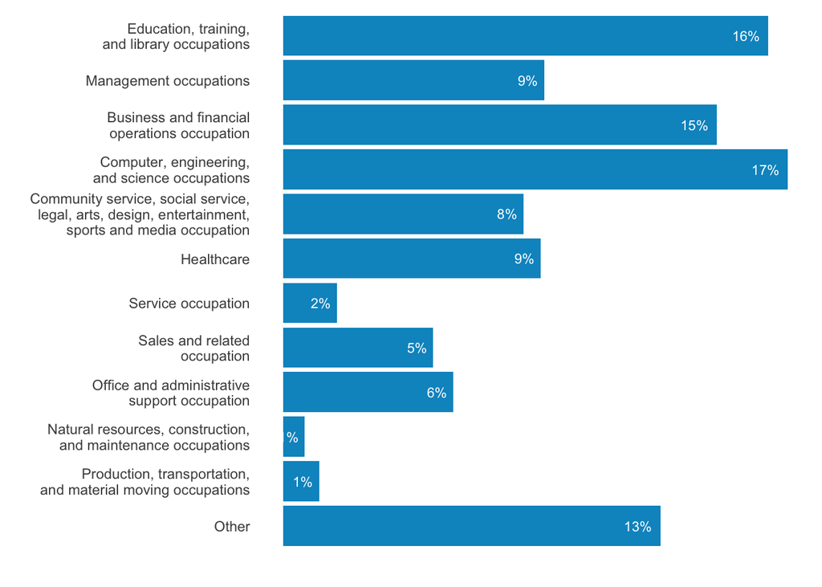

```r
tmp <- tmp %>% select(var, perc)

strada1(tmp)
```

# Summary findings

## Achieved goals

My school education helped me achieve my goals

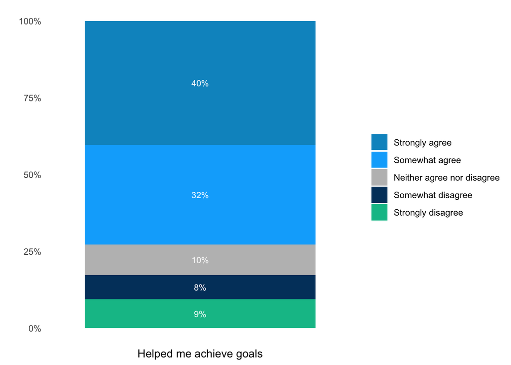

```r
tmp <- as.data.frame(svytable(~q37, sch.w))
tmp$perc <- tmp$Freq/sum(tmp$Freq)
names(tmp)[1] <- "var"
tmp$var2 <- "Helped me achieve goals"

strada2(tmp, "Helped me achieve goals")
```

## Cost Value

My school education was worth the cost

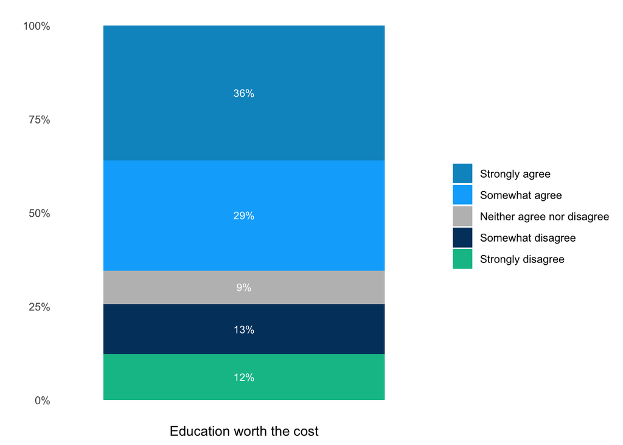

```r
tmp <- as.data.frame(svytable(~q30, sch.w))
tmp$perc <- tmp$Freq/sum(tmp$Freq)
names(tmp)[1] <- "var"
tmp$var2 <- "Education worth the cost"

tmp$var <- factor(tmp$var,
                  levels = c(
                    "Strongly agree",
                    "Somewhat agree",
                    "Neither agree nor disagree",
                    "Somewhat disagree",
                    "Strongly disagree"
                    )
                  )

strada2(tmp, "Education worth the cost")
```

## Income

Annual income before taxes

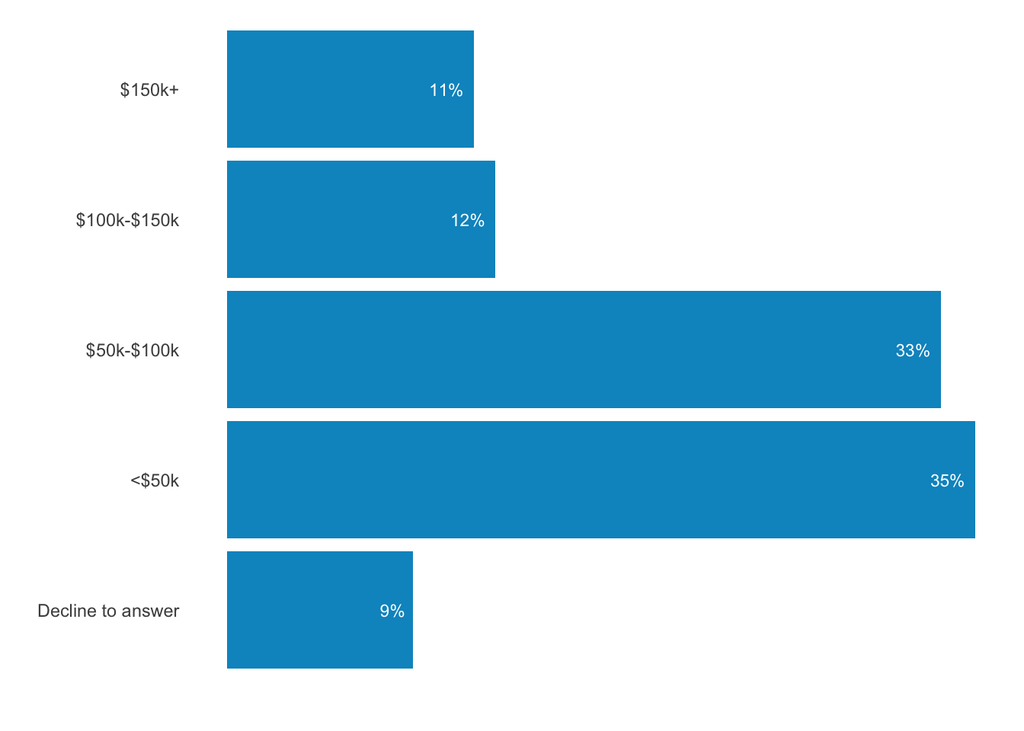

```r
tmp <- as.data.frame(svytable(~q131r, sch.w))
tmp$perc <- tmp$Freq/sum(tmp$Freq)
names(tmp)[1] <- "var"



strada1(tmp)
```

# Summary findings by sub-group

- Total
- Students of color
- First gen
- Female
- Non-trad (What is non-trad?)
- Graduated in past 10 years

## Achieved goals - Cost Value - Income

### My school education helped me achieve my goals

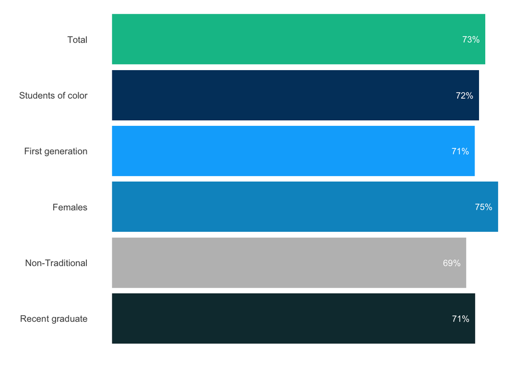

```r
# Function for subgroup bar charts

subg <- ad_subg_tab("q37", sch.w)

strada3(subg)
```

```r
subg1 <- subg
```

### My school education was worth the cost

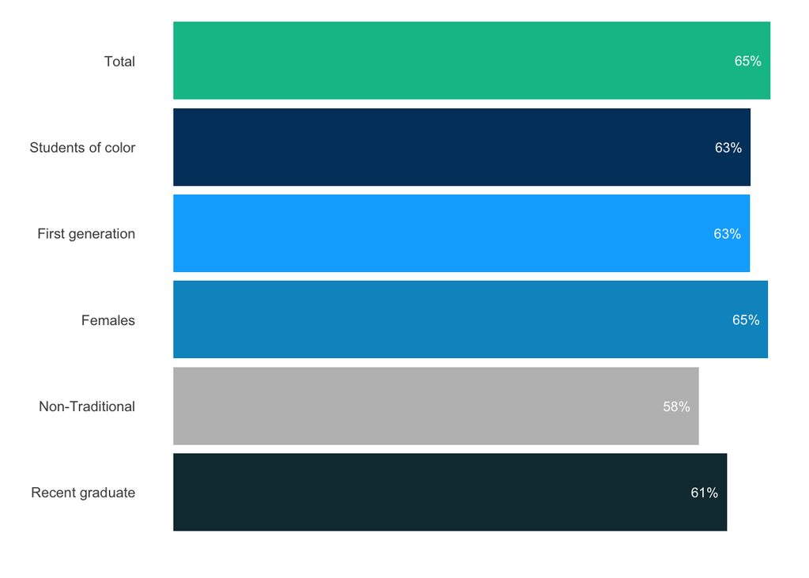

```r
subg <- ad_subg_tab("q30", sch.w)

strada3(subg)
```

```r
subg2 <- subg
```

### Annual income before taxes >$50k

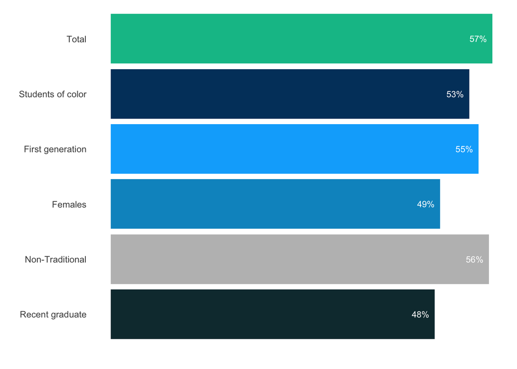

```r
# Custom code to handle income instead of A/D scale.

tot <- as.data.frame(svytable(~q131r, sch.w))
tot$grp <- "Total"
tot$var <- "Total"
names(tot)[1] <- "val"
tot <- tot %>% group_by(grp, var) %>%
  mutate(perc = Freq/sum(Freq)) %>%
  select(grp, var, val, Freq, perc)

soc <- as.data.frame(svytable(~q131r+soc, sch.w))
soc$grp <- "soc"
names(soc)[2] <- "var"
names(soc)[1] <- "val"
soc <- soc %>% group_by(grp, var) %>%
  mutate(perc = Freq/sum(Freq)) %>%
  select(grp, var, val, Freq, perc)

fgen <- as.data.frame(svytable(~q131r+fgen, sch.w))
fgen$grp <- "fgen"
names(fgen)[2] <- "var"
names(fgen)[1] <- "val"
fgen <- fgen %>% group_by(grp, var) %>%
  mutate(perc = Freq/sum(Freq)) %>%
  select(grp, var, val, Freq, perc)

fem <- as.data.frame(svytable(~q131r+q274, sch.w))
fem$grp <- "fem"
names(fem)[2] <- "var"
names(fem)[1] <- "val"
fem <- fem %>% group_by(grp, var) %>%
  mutate(perc = Freq/sum(Freq)) %>%
  select(grp, var, val, Freq, perc)

ntrad <- as.data.frame(svytable(~q131r+ntrad, sch.w))
ntrad$grp <- "ntrad"
names(ntrad)[2] <- "var"
names(ntrad)[1] <- "val"
ntrad <- ntrad %>% group_by(grp, var) %>%
  mutate(perc = Freq/sum(Freq)) %>%
  select(grp, var, val, Freq, perc)

recg <- as.data.frame(svytable(~q131r+recg, sch.w))
recg$grp <- "recg"
names(recg)[2] <- "var"
names(recg)[1] <- "val"
recg <- recg %>% group_by(grp, var) %>%
  mutate(perc = Freq/sum(Freq)) %>%
  select(grp, var, val, Freq, perc)

subg <- bind_rows(tot, soc, fgen, fem, ntrad, recg)

subg <- subg %>%
  filter(var %in% c(
    "Total", "Yes", "Not White", "Woman"
    )
  ) %>%
  filter(val %in% c("$150k+", "$100k-$150k", "$50k-$100k")) %>%
  group_by(grp) %>%
  summarize(perc = sum(perc))

subg$grp <- factor(subg$grp,
                   levels = c("Total", "soc", "fgen", "fem", "ntrad", "recg"),
                   labels = c("Total", "Students of color", "First generation", "Females", "Non-Traditional", "Recent graduate")
)

strada3(subg)
```

```r
subg3 <- subg
```

### Combined table?

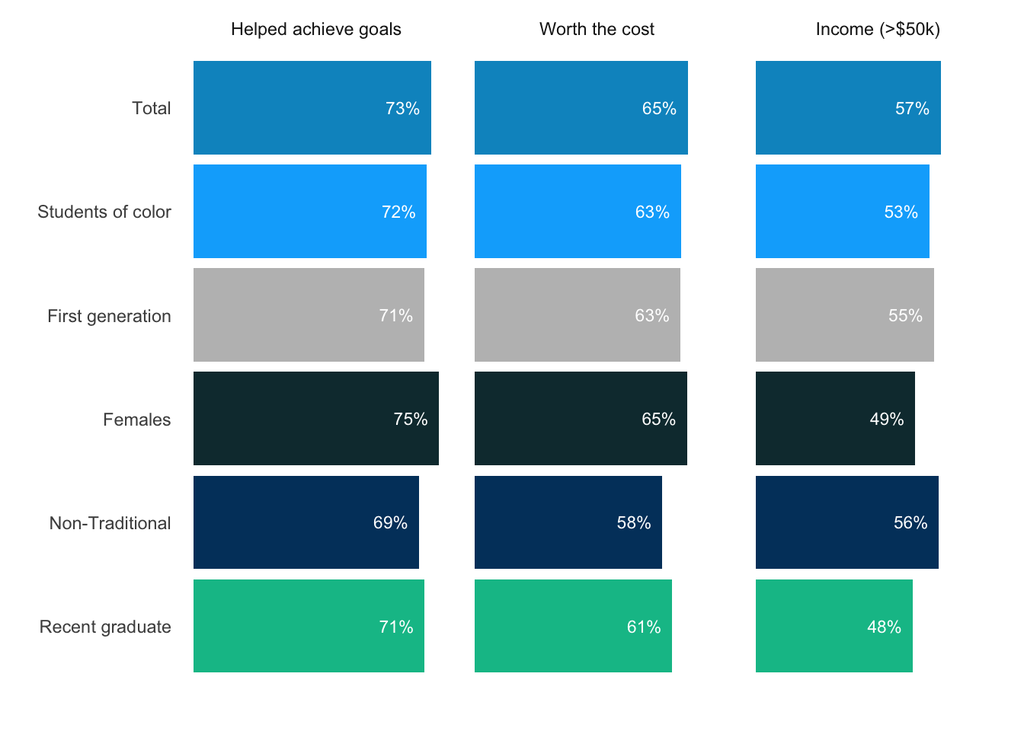

```r
subg1$var <- "Helped achieve goals"
subg2$var <- "Worth the cost"
subg3$var <- "Income (>$50k)"

subg <- bind_rows(subg1, subg2, subg3)

subg$var <- factor(subg$var,
                   levels = c("Helped achieve goals",
                              "Worth the cost",
                              "Income (>$50k)"
                              )
                   )


ggplot(subg, aes(grp, perc, label=scales::percent(perc, 1.0), fill=grp)) +
    geom_col() +
    geom_text(
      color = "white",
      hjust = 1.3,
      size = 3
    ) +
    coord_flip() +
    scale_y_continuous(labels = scales::percent) +
    scale_x_discrete(limits = rev) +
    theme_minimal() +
    labs(x="", y="") +
    theme(
      panel.border = element_blank(),
      panel.grid.major = element_blank(),
      panel.grid.minor = element_blank(),
      axis.text.x = element_blank(),
      legend.position = "none"
    ) +
    scale_fill_manual(values = colr2) +
    facet_wrap(vars(var))
```

# Net Benefit scores

Value

- Is worth the cost
- Helped me support self and family
- Helped make more money
- Impact on financial circumstances

Life Impact

- Impact on community engagement
- Impact on quality of life
- Helped me learn new things
- Helped me become the best person I can be
- Helped me become a good role model

Career satisfaction

- Impact on success at work
- Helped me to qualify for good jobs
- Helped me to advance my career
- Makes/made me an attractive candidate for potential employers
- Makes/made me an attractive candidate for graduate or professional school
- Helped me gain skills to be successful in work
- Satisfaction with current job/career

Skill development

- Critical Thinking/Problem Solving
- Verbal Communication/ Speaking
- Writing
- Leadership
- Data Analysis/Statistics
- Teamwork
- Digital Literacy
- Math
- Project Management
- Ability to learn new things
- Creativity

Affinity

- When someone praises …, it feels like a personal compliment
- If a story in the media criticized …, I would feel embarrassed
- It’s important to me to remain engaged with …
- Likelihood to recommend
- Interested in talking to current students about work and career
- Interested in serving as a mentor for current students
- Interested in providing a job shadowing experience for current students

## Net benefit profile

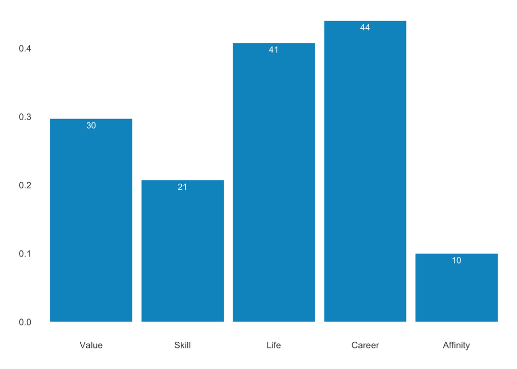

```r
value = nb_value(sch.w)
life = nb_life(sch.w)
career = nb_career(sch.w)
skill = nb_skill(sch.w)
affinity = nb_affinity(sch.w)

nb_profile <- bind_rows(value, life, career, skill, affinity)

strada4(nb_profile)
```

# Net Benefit scores by sub-group

- Total
- Students of color
- First gen
- Female
- Non-trad (What is non-trad?)
- Graduated in past 10 years

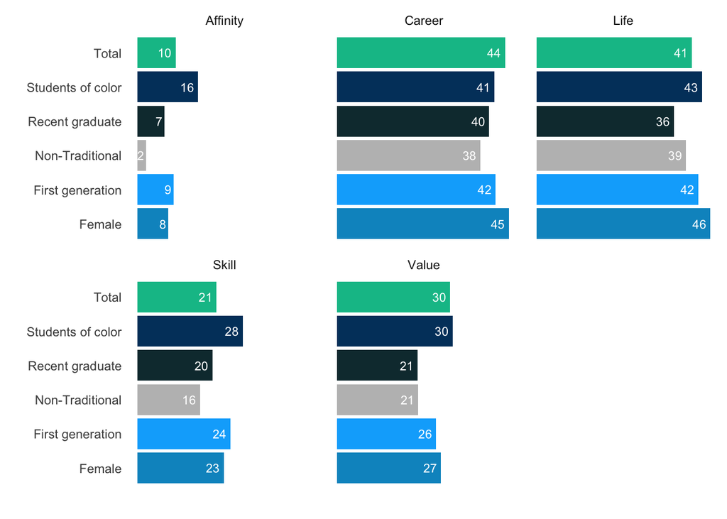

```r
t_nb_profile <- nb_profile %>% mutate(grp = "Total")

# SOC
value = nb_value(subset(sch.w, soc == "Not White"))
life = nb_life(subset(sch.w, soc == "Not White"))
career = nb_career(subset(sch.w, soc == "Not White"))
skill = nb_skill(subset(sch.w, soc == "Not White"))
affinity = nb_affinity(subset(sch.w, soc == "Not White"))

soc_nb_profile <- bind_rows(value, life, career, skill, affinity) %>%
  mutate(grp = "Students of color")

# First gen
value = nb_value(subset(sch.w, fgen == "Yes"))
life = nb_life(subset(sch.w, fgen == "Yes"))
career = nb_career(subset(sch.w, fgen == "Yes"))
skill = nb_skill(subset(sch.w, fgen == "Yes"))
affinity = nb_affinity(subset(sch.w, fgen == "Yes"))

fgen_nb_profile <- bind_rows(value, life, career, skill, affinity) %>%
  mutate(grp = "First generation")

# Female
value = nb_value(subset(sch.w, q274 == "Woman"))
life = nb_life(subset(sch.w, q274 == "Woman"))
career = nb_career(subset(sch.w, q274 == "Woman"))
skill = nb_skill(subset(sch.w, q274 == "Woman"))
affinity = nb_affinity(subset(sch.w, q274 == "Woman"))

fem_nb_profile <- bind_rows(value, life, career, skill, affinity) %>%
  mutate(grp = "Female")

# Non-traditional
value = nb_value(subset(sch.w, ntrad == "Yes"))
life = nb_life(subset(sch.w, ntrad == "Yes"))
career = nb_career(subset(sch.w, ntrad == "Yes"))
skill = nb_skill(subset(sch.w, ntrad == "Yes"))
affinity = nb_affinity(subset(sch.w, ntrad == "Yes"))

ntrad_nb_profile <- bind_rows(value, life, career, skill, affinity) %>%
  mutate(grp = "Non-Traditional")

# Recent
value = nb_value(subset(sch.w, recg == "Yes"))
life = nb_life(subset(sch.w, recg == "Yes"))
career = nb_career(subset(sch.w, recg == "Yes"))
skill = nb_skill(subset(sch.w, recg == "Yes"))
affinity = nb_affinity(subset(sch.w, recg == "Yes"))

recg_nb_profile <- bind_rows(value, life, career, skill, affinity) %>%
  mutate(grp = "Recent graduate")

subg_nb_profile <- bind_rows(t_nb_profile,
                             soc_nb_profile,
                             fgen_nb_profile,
                             fem_nb_profile,
                             ntrad_nb_profile,
                             recg_nb_profile)

ggplot(subg_nb_profile, aes(grp, nb, label=round(nb*100, 0), fill=grp)) +
    geom_col() +
    geom_text(
      color = "white",
      hjust = 1.3,
      size = 3
    ) +
    coord_flip() +
    theme_minimal() +
    labs(x="", y="") +
    theme(
      panel.border = element_blank(),
      panel.grid.major = element_blank(),
      panel.grid.minor = element_blank(),
      axis.text.x = element_blank(),
      legend.position = "none"
    ) +
    scale_fill_manual(values = colr2) +
    facet_wrap(vars(var))
```

# Peer benchmarking: Net benefit profile

- You, national, avg peer benchmark, pb high, pb low

**Question:** Are we doing this?

# Detailed findings

**Note:** Switched to horizontal layout as suggested

## Net benefit profile - Value

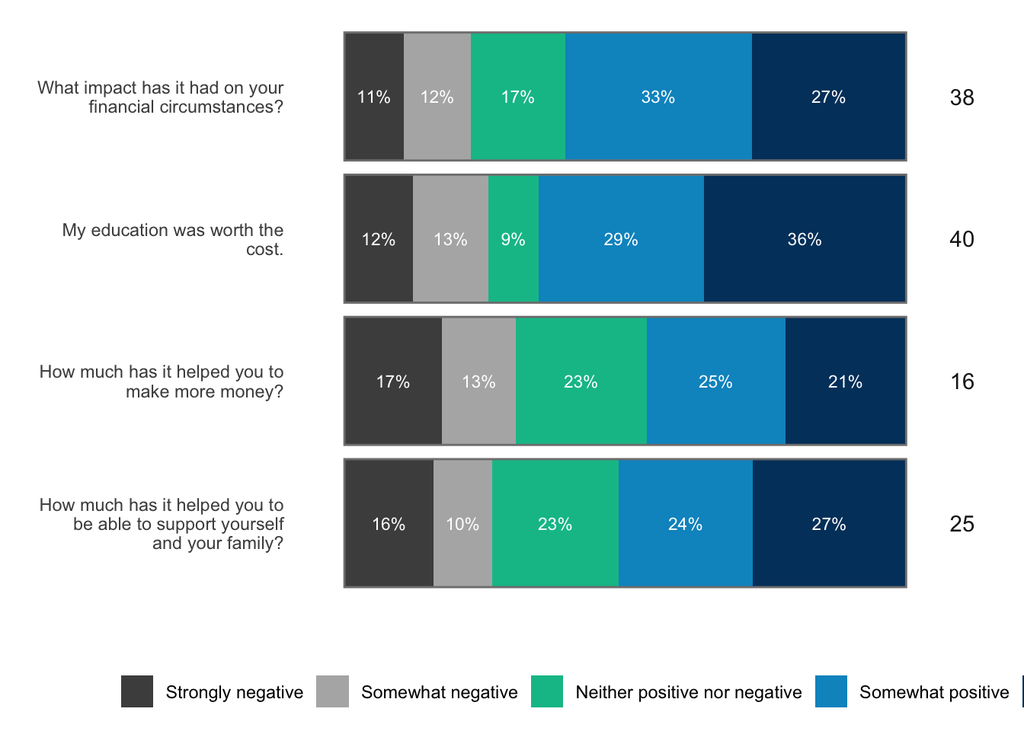

```r
value <- dnb_value(sch.w)

value$dummy <- 1
value$pos <- 1.1

d1 <- dict %>%
  select(var = uvar, label) %>% unique()

value <- left_join(value, d1)

v1 <- value %>%
#  select(var:val5) %>%
  pivot_longer(
    val1:val5,
    names_to = "var2",
    values_to = "perc"
  )

v1$var22 <- case_when(
  v1$var2 == "val1" ~ "Strongly negative",
  v1$var2 == "val2" ~ "Somewhat negative",
  v1$var2 == "val3" ~ "Neither positive nor negative",
  v1$var2 == "val4" ~ "Somewhat positive",
  v1$var2 == "val5" ~ "Strongly positive",
)

v1$var22 <- factor(v1$var22,
                    levels = c(
                       "Strongly positive",
                       "Somewhat positive",
                       "Neither positive nor negative",
                       "Somewhat negative",
                       "Strongly negative"
                    )
                  )

strada5(v1, value)
```

## Net benefit profile - Life impact

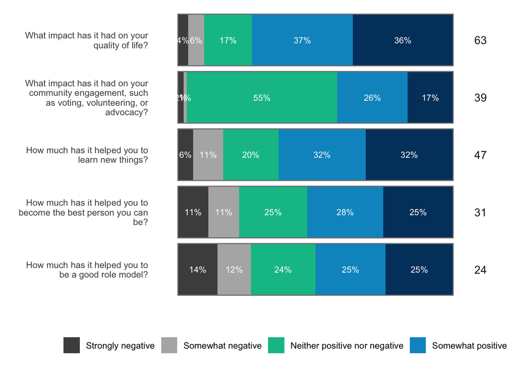

```r
life <- dnb_life(sch.w)

life$dummy <- 1
life$pos <- 1.1

d1 <- dict %>%
  select(var = uvar, label) %>% unique()

life <- left_join(life, d1)

v1 <- life %>%
#  select(var:val5) %>%
  pivot_longer(
    val1:val5,
    names_to = "var2",
    values_to = "perc"
  )

v1$var22 <- case_when(
  v1$var2 == "val1" ~ "Strongly negative",
  v1$var2 == "val2" ~ "Somewhat negative",
  v1$var2 == "val3" ~ "Neither positive nor negative",
  v1$var2 == "val4" ~ "Somewhat positive",
  v1$var2 == "val5" ~ "Strongly positive",
)

v1$var22 <- factor(v1$var22,
                    levels = c(
                       "Strongly positive",
                       "Somewhat positive",
                       "Neither positive nor negative",
                       "Somewhat negative",
                       "Strongly negative"
                    )
                  )

strada5(v1, life)
```

## Net benefit profile - Career

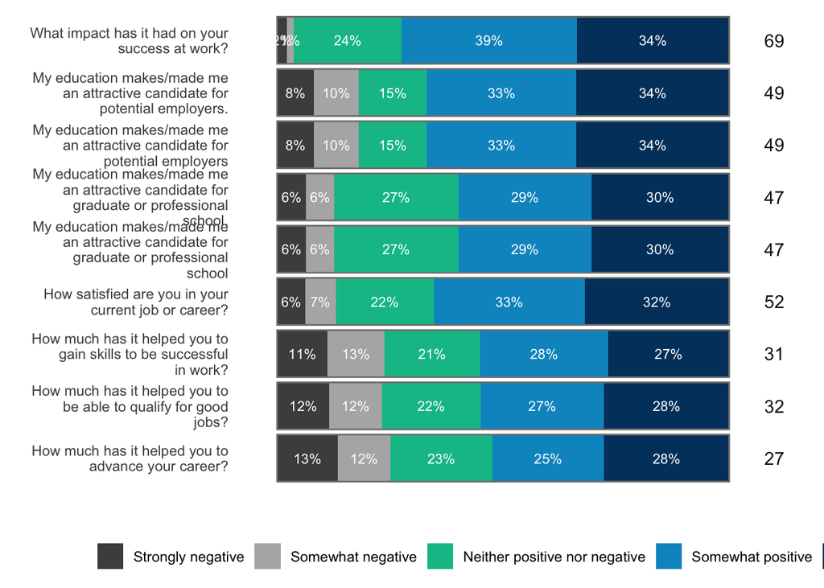

```r
career <- dnb_career(sch.w)

career$dummy <- 1
career$pos <- 1.1

d1 <- dict %>%
  select(var = uvar, label) %>% unique()

career <- left_join(career, d1)

v1 <- career %>%
#  select(var:val5) %>%
  pivot_longer(
    val1:val5,
    names_to = "var2",
    values_to = "perc"
  )

v1$var22 <- case_when(
  v1$var2 == "val1" ~ "Strongly negative",
  v1$var2 == "val2" ~ "Somewhat negative",
  v1$var2 == "val3" ~ "Neither positive nor negative",
  v1$var2 == "val4" ~ "Somewhat positive",
  v1$var2 == "val5" ~ "Strongly positive",
)

v1$var22 <- factor(v1$var22,
                    levels = c(
                       "Strongly positive",
                       "Somewhat positive",
                       "Neither positive nor negative",
                       "Somewhat negative",
                       "Strongly negative"
                    )
                  )

strada5(v1, career)
```

## Net benefit profile - Skill dev

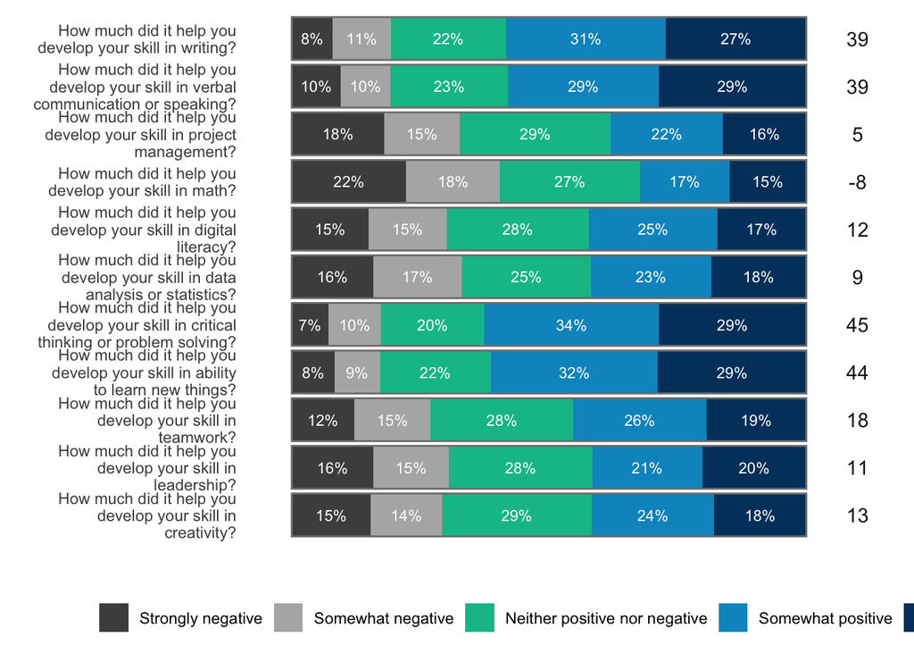

```r
skill <- dnb_skill(sch.w)

skill$dummy <- 1
skill$pos <- 1.1

d1 <- dict %>%
  select(var = uvar, label) %>% unique()

skill <- left_join(skill, d1)

v1 <- skill %>%
#  select(var:val5) %>%
  pivot_longer(
    val1:val5,
    names_to = "var2",
    values_to = "perc"
  )

v1$var22 <- case_when(
  v1$var2 == "val1" ~ "Strongly negative",
  v1$var2 == "val2" ~ "Somewhat negative",
  v1$var2 == "val3" ~ "Neither positive nor negative",
  v1$var2 == "val4" ~ "Somewhat positive",
  v1$var2 == "val5" ~ "Strongly positive",
)

v1$var22 <- factor(v1$var22,
                    levels = c(
                       "Strongly positive",
                       "Somewhat positive",
                       "Neither positive nor negative",
                       "Somewhat negative",
                       "Strongly negative"
                    )
                  )

strada5(v1, skill)
```

## Net benefit profile - Affinity

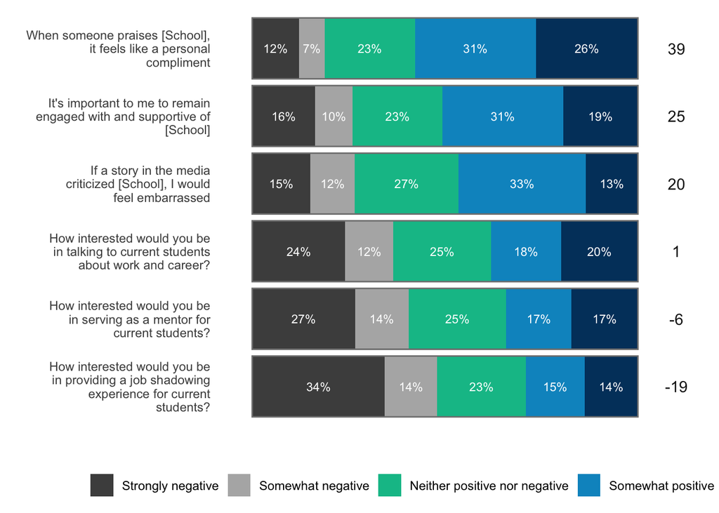

```r
affinity <- dnb_affinity(sch.w)

affinity$dummy <- 1
affinity$pos <- 1.1

d1 <- dict %>%
  select(var = uvar, label) %>% unique()

affinity <- left_join(affinity, d1)

v1 <- affinity %>%
#  select(var:val5) %>%
  pivot_longer(
    val1:val5,
    names_to = "var2",
    values_to = "perc"
  )

v1$var22 <- case_when(
  v1$var2 == "val1" ~ "Strongly negative",
  v1$var2 == "val2" ~ "Somewhat negative",
  v1$var2 == "val3" ~ "Neither positive nor negative",
  v1$var2 == "val4" ~ "Somewhat positive",
  v1$var2 == "val5" ~ "Strongly positive",
)

v1$var22 <- factor(v1$var22,
                    levels = c(
                       "Strongly positive",
                       "Somewhat positive",
                       "Neither positive nor negative",
                       "Somewhat negative",
                       "Strongly negative"
                    )
                  )

strada5(v1, affinity)
```

## Value contributed to overall experience

Classes … Alumni network

## Impact on securing first job: Reputation and Resources

- Benefit score
- Bar chart SA-SD

Bach degree … Alumni network

## Value of skills in your current job

- Benefit score
- Bar chart SA-SD

Critical thinking … Math

## Developed skills: Value perceptions

- How much did your education help you develop the following skills?.
- Looking at the same list of skills you reviewed earlier in the survey, please indicate how valuable each one is in your current job.

Critical thinking … Creativity

## Educational goals: Reasons for pursuing education and outcomes

Be able to qualify for good jobs … Be a good role model

## Perspectives on student loans

- Total borrowed in student loans
- It was worth taking out loans to get BA.

# Appendix

## Additional demographics

- Gender
- Current age
- Graduation year
- Hisp/Latinx origin
- Race ethnicity